# 3dayGroup3fitAndPlot

Alex Holcombe

2/8/2018

Load some data. Group 3 means all serial positions were used.

```r
load( file.path("dataRaw",'three_day.RData') )
library(dplyr)
#mixRSVP requires that dataframe that must have fields targetSP and SPE
names(three_day)[names(three_day) == 'TargPos'] <- 'targetSP'
names(three_day)[names(three_day) == 'Distance'] <- 'SPE'
#group 3 were trained on all serial positions
three3<- three_day %>% filter(Group==3)
# for the 3-Day condition, the training blocks (all serial positions 3-14) were
# blocks 2-7, 9-14, and 16-18  (blocks 1, 8, and 15 were "practice blocks" of 10 or so trials).
blocks<-c(2:7,9:14,16:18) #training blocks for group 3
three3t <- three3 %>% filter(Block %in% blocks)
#Exclude trials where target was not presented
three3t <- three3t %>% filter(targetSP != 0)
#Exclude other cases where SPE not applicable
#Response.Pos == False indicates either     a) the participant reported "0"
# b) there was no target on that trial
# c) the participant reported a stimulus that was not presented
three3t <- three3t %>% filter(Response.Pos != FALSE)


data <-three3t
numItemsInStream<- 16 #from their Methods section
# SOA of 80 ms
#blue letter but were unsure what it was.  Participants responded using the 0 (zero) key to indicate that there was no blue letter on the catch trials.
df<-data
```

Install the mixture modeling R library

```r
#devtools::install_github('alexholcombe/mixRSVP',build_vignettes=TRUE)  #If want latest version
library(mixRSVP)
```

Set up the experiment-specific parameters

````r
annotateIt<-TRUE
minSPE<- -13 #targetSP = 14, subject reports first letter in stream (1)
maxSPE<- 13 #targetSP = 3 and response position is 16```
````

Inspect strange case of subject #915. Turns out it’s actually fine, it’s just that they didn’t report seeing a letter very often, so it doesn’t show up on the graph with common scale at bottom.

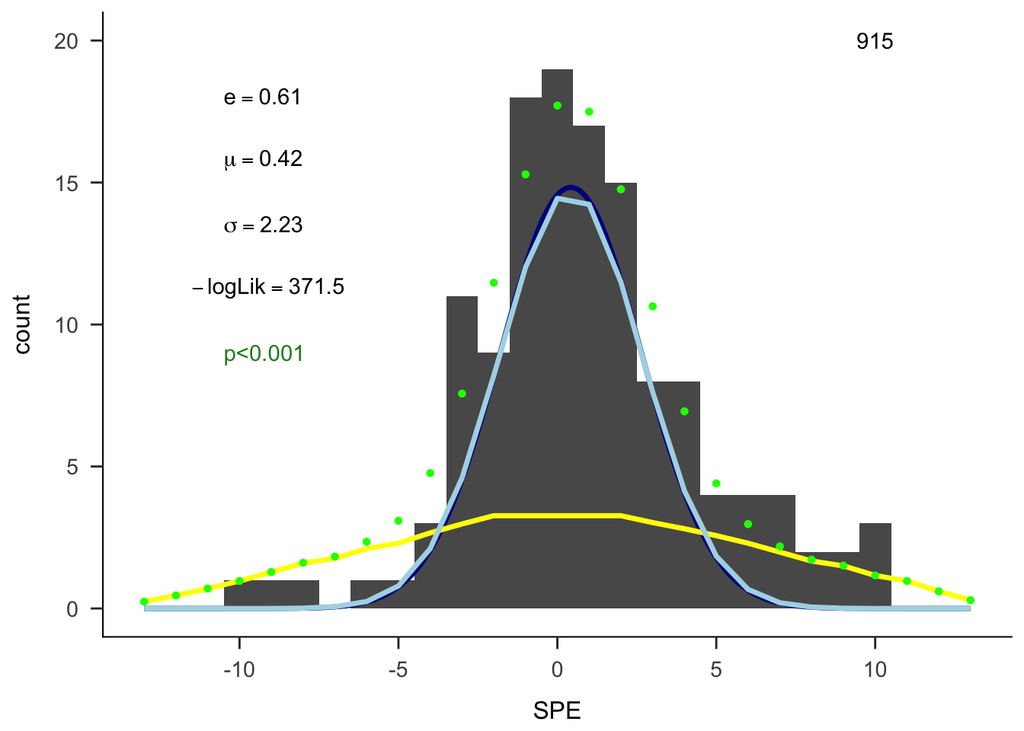

Fitted guessing distribution in yellow, discretized Gaussian in light blue, combined in green, dark blue is continuous Gaussian

[figure not shown]

Fitted guessing distribution in yellow, discretized Gaussian in light blue, combined in green, dark blue is continuous Gaussian

Fit mixture model to whole dataset and print a bit of the results

```
## [1] "calculate= FALSE"
```

[output not shown]

```
## # A tibble: 6 x 8
## # Groups:   Subject [6]
##   Subject efficacy latency precision   val warnings  valGuessing   pLRtest
##     <int>    <dbl>   <dbl>     <dbl> <dbl> <chr>           <dbl>     <dbl>
## 1      90    0.884  0.0895 0.374       823 None             1987 0
## 2      91    0.614 -0.0197 0.768      1397 None             1742 4.89e⁻¹⁴⁹
## 3      92    0.725  0.0337 0.0000100   884 "list(me…        1883 0
## 4      93    0.779  0.0851 0.487      1121 None             1894 0
## 5      94    0.771  0.0323 0.459      1100 None             1851 0
## 6      95    0.735 -0.147  0.883      1377 None             1850 1.63e⁻²⁰⁴
```

Plot all data with fits.

I think you can’t put it all into a single plot by calling plot_hist_with_fit multiple times because it returns a plot object, then would have to use grid or something to combine the plots.

So, the method here is to calculate the fitted curves separately and then add them on. There should be a more integrated way to do that but then it might be harder to probe when fits go wrong?

First calculate the fitted curves.

```r
#want fig.height of 10 per subject

#Add R parameter estimates to dataframe
dg<- merge(df,estimates)

curves<- dg %>% group_by_at(.vars = condtnVariableNames) %>%
  do(calc_curves_dataframe(.,minSPE,maxSPE,numItemsInStream))
```

Now calculate the number of observations in each condition, which is used for scaling the pseudo-continuous (fine-grained) Gaussian. Then calculate that Gaussian curve.

```r
#Calc numObservations to each condition. This is needed only for scaling the fine-grained Gaussian
#Calc the number of observations for each condition, because gaussianScaledforData needs to know.
dfGroups<- dg %>% group_by_at(.vars = condtnVariableNames) %>% summarise(nPerCond = n())
#add nPerCond back to parameter estimates
estimates<- merge(estimates,dfGroups)


grain<-.05
gaussFine<- estimates %>% group_by_at(.vars = condtnVariableNames) %>% do(
  gaussian_scaled_from_df(.,minSPE,maxSPE,grain) )
```

Plot histogram and fit for each subject

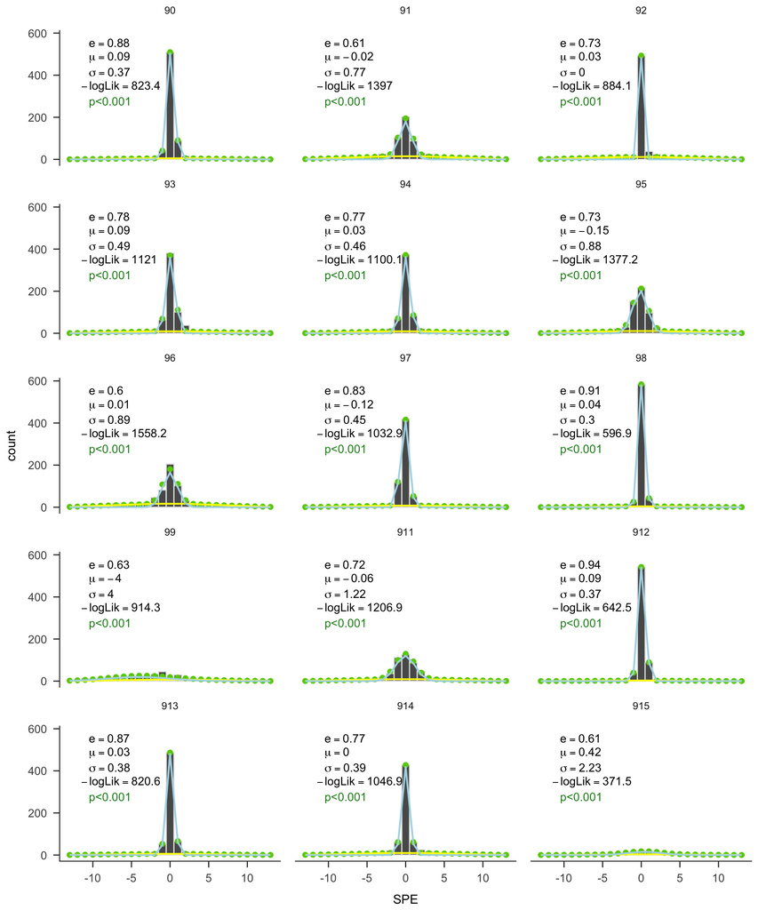